# Football Player dataset collation

J. Heffaran

2026-10-06

# Player data for premier league seasons (2020-21, …, 2024-25)

I am collating football player data, which we could potentially use to create a squad rating metric. We could engineer this feature, and use it as part of our regression analysis in sprint 1, where we hope to predict the outcomes of football games.

We will use the worldfootballR package which saves me a bit of time. This package is used to collect data from fbref.

We use it to access collected player data for the seasons ending in 2021,…, 2025. This is since the package was last updated in the 2025-26 season.

```r
#--- Installing packages ---#
#install.packages("worldfootballR")
```

```r
#--- Library funstuff ---#
library(tidyverse)
library(worldfootballR)
```

First, we shall create our csv files using the worldfootball package.

```r
seasons <- c(2025, 2024, 2023, 2022, 2021)

for (season in seasons){
  player_data <- load_fb_big5_advanced_season_stats(
    season_end_year = season,
    stat_type  = "standard",
    team_or_player = "player"
  )

  #---keep only prem data---#
  player_data <- subset(player_data, Comp == "Premier League")

  write.csv(
    player_data,
    paste0("premier_league_", season -1, "-", substr(season,3,4), "_player_data.csv"),
    row.names = FALSE
  )
}
```

```
## → Data last updated 2025-09-18 17:39:32.777853012085 UTC
## → Data last updated 2025-09-18 17:39:32.777853012085 UTC
## → Data last updated 2025-09-18 17:39:32.777853012085 UTC
## → Data last updated 2025-09-18 17:39:32.777853012085 UTC
## → Data last updated 2025-09-18 17:39:32.777853012085 UTC
```

Lets begin by looking at the headers of the data, see what we are being given.

```r
df = read_csv("premier_league_2024-25_player_data.csv")
head(df)
```

```
## # A tibble: 6 × 38
##   Season_End_Year Squad   Comp        Player Nation Pos     Age  Born MP_Playing
##             <dbl> <chr>   <chr>       <chr>  <chr>  <chr> <dbl> <dbl>      <dbl>
## 1            2025 Arsenal Premier Le… Natha… ENG    FW       21  2003          1
## 2            2025 Arsenal Premier Le… Ricca… ITA    DF       22  2002         19
## 3            2025 Arsenal Premier Le… Kai H… GER    FW,MF    25  1999         23
## 4            2025 Arsenal Premier Le… Gabri… BRA    FW       27  1997         17
## 5            2025 Arsenal Premier Le… Jorgi… ITA    MF       32  1991         15
## 6            2025 Arsenal Premier Le… Jakub… POL    DF       24  2000         17
## # ℹ 29 more variables: Starts_Playing <dbl>, Min_Playing <dbl>,
## #   Mins_Per_90_Playing <dbl>, Gls <dbl>, Ast <dbl>, `G+A` <dbl>,
## #   G_minus_PK <dbl>, PK <dbl>, PKatt <dbl>, CrdY <dbl>, CrdR <dbl>,
## #   PrgC_Progression <dbl>, PrgP_Progression <dbl>, PrgR_Progression <dbl>,
## #   Gls_Per <dbl>, Ast_Per <dbl>, `G+A_Per` <dbl>, G_minus_PK_Per <dbl>,
## #   `G+A_minus_PK_Per` <dbl>, xG_Expected <dbl>, npxG_Expected <dbl>,
## #   xAG_Expected <dbl>, `npxG+xAG_Expected` <dbl>, xG_Per <dbl>, …
```

```r
names(df)
```

```
##  [1] "Season_End_Year"     "Squad"               "Comp"
##  [4] "Player"              "Nation"              "Pos"
##  [7] "Age"                 "Born"                "MP_Playing"
## [10] "Starts_Playing"      "Min_Playing"         "Mins_Per_90_Playing"
## [13] "Gls"                 "Ast"                 "G+A"
## [16] "G_minus_PK"          "PK"                  "PKatt"
## [19] "CrdY"                "CrdR"                "PrgC_Progression"
## [22] "PrgP_Progression"    "PrgR_Progression"    "Gls_Per"
## [25] "Ast_Per"             "G+A_Per"             "G_minus_PK_Per"
## [28] "G+A_minus_PK_Per"    "xG_Expected"         "npxG_Expected"
## [31] "xAG_Expected"        "npxG+xAG_Expected"   "xG_Per"
## [34] "xAG_Per"             "xG+xAG_Per"          "npxG_Per"
## [37] "npxG+xAG_Per"        "Url"
```

Okay lovely stuff, these are all pretty common football related stats. Most are pretty self explanatory, but for reference I have translated headers to plain english below (NOTE: LLMS HAVE BEEN USED FOR THIS ARDUOUS WORK):

## 1. Player / season information

| Column | Meaning |
| --- | --- |
| `Season_End_Year` | The year the season ended. E.g. `2025` means the 2024–25 season. |
| `Squad` | The player’s team. |
| `Comp` | The competition. |
| `Player` | Player’s name. |
| `Nation` | Player’s nationality. |
| `Pos` | Player’s position. |
| `Age` | Player’s age during the season. |
| `Born` | Player’s birth year. |

## 2. Playing time

| Column | Meaning |
| --- | --- |
| `MP_Playing` | Matches played. |
| `Starts_Playing` | Matches started. |
| `Min_Playing` | Total minutes played. |
| `Mins_Per_90_Playing` | Minutes played expressed as 90-minute games. |

## 3. Goals and assists

| Column | Meaning |
| --- | --- |
| `Gls` | Goals scored. |
| `Ast` | Assists. |
| `G+A` | Goals + assists. |
| `G_minus_PK` | Goals excluding penalties. |
| `PK` | Penalties scored. |
| `PKatt` | Penalties attempted. |

## 4. Discipline

| Column | Meaning |
| --- | --- |
| `CrdY` | Yellow cards. |
| `CrdR` | Red cards. |

## 5. Ball progression

| Column | Meaning |
| --- | --- |
| `PrgC_Progression` | Progressive carries: carrying the ball forwards significantly. |
| `PrgP_Progression` | Progressive passes: passes that significantly advance the ball. |
| `PrgR_Progression` | Progressive passes received: receiving the ball in positions that significantly advance play. |

## 6. Per-90 statistics

| Column | Meaning |
| --- | --- |
| `Gls_Per` | Goals per 90 minutes. |
| `Ast_Per` | Assists per 90 minutes. |
| `G+A_Per` | Goals + assists per 90 minutes. |
| `G_minus_PK_Per` | Non-penalty goals per 90 minutes. |
| `G+A_minus_PK_Per` | Non-penalty goals + assists per 90 minutes. |

## 7. Expected goals (xG) and expected assists (xAG)

| Column | Meaning |
| --- | --- |
| `xG_Expected` | Expected goals. |
| `npxG_Expected` | Expected goals excluding penalties. |
| `xAG_Expected` | Expected assists. |
| `npxG+xAG_Expected` | Non-penalty expected goals + expected assists. |

## 8. Expected statistics per 90

| Column | Meaning |
| --- | --- |
| `xG_Per` | Expected goals per 90 minutes. |
| `xAG_Per` | Expected assists per 90 minutes. |
| `xG+xAG_Per` | Expected goals + expected assists per 90 minutes. |
| `npxG_Per` | Non-penalty expected goals per 90 minutes. |
| `npxG+xAG_Per` | Non-penalty expected goals + expected assists per 90 minutes. |

Now we have a cribsheet for reference to if needed.

Lets have a look at the summary of this data

```r
summary(df)
```

```
##  Season_End_Year    Squad               Comp              Player
##  Min.   :2025    Length:574         Length:574         Length:574
##  1st Qu.:2025    Class :character   Class :character   Class :character
##  Median :2025    Mode  :character   Mode  :character   Mode  :character
##  Mean   :2025
##  3rd Qu.:2025
##  Max.   :2025
##
##     Nation              Pos                 Age            Born
##  Length:574         Length:574         Min.   :15.0   Min.   :1985
##  Class :character   Class :character   1st Qu.:22.0   1st Qu.:1996
##  Mode  :character   Mode  :character   Median :25.0   Median :1999
##                                        Mean   :25.1   Mean   :1999
##                                        3rd Qu.:28.0   3rd Qu.:2002
##                                        Max.   :39.0   Max.   :2008
##                                        NA's   :4      NA's   :4
##    MP_Playing    Starts_Playing   Min_Playing     Mins_Per_90_Playing
##  Min.   : 1.00   Min.   : 0.00   Min.   :   1.0   Min.   : 0.00
##  1st Qu.: 9.00   1st Qu.: 3.00   1st Qu.: 331.2   1st Qu.: 3.70
##  Median :21.00   Median :12.00   Median :1103.5   Median :12.25
##  Mean   :20.15   Mean   :14.56   Mean   :1308.2   Mean   :14.54
##  3rd Qu.:32.00   3rd Qu.:25.00   3rd Qu.:2204.0   3rd Qu.:24.50
##  Max.   :38.00   Max.   :38.00   Max.   :3420.0   Max.   :38.00
##
##       Gls              Ast              G+A           G_minus_PK
##  Min.   : 0.000   Min.   : 0.000   Min.   : 0.000   Min.   : 0.000
##  1st Qu.: 0.000   1st Qu.: 0.000   1st Qu.: 0.000   1st Qu.: 0.000
##  Median : 0.000   Median : 0.000   Median : 1.000   Median : 0.000
##  Mean   : 1.885   Mean   : 1.401   Mean   : 3.286   Mean   : 1.765
##  3rd Qu.: 2.000   3rd Qu.: 2.000   3rd Qu.: 4.000   3rd Qu.: 2.000
##  Max.   :29.000   Max.   :18.000   Max.   :47.000   Max.   :20.000
##
##        PK             PKatt             CrdY             CrdR
##  Min.   :0.0000   Min.   :0.0000   Min.   : 0.000   Min.   :0.00000
##  1st Qu.:0.0000   1st Qu.:0.0000   1st Qu.: 0.000   1st Qu.:0.00000
##  Median :0.0000   Median :0.0000   Median : 2.000   Median :0.00000
##  Mean   :0.1202   Mean   :0.1446   Mean   : 2.784   Mean   :0.09059
##  3rd Qu.:0.0000   3rd Qu.:0.0000   3rd Qu.: 4.750   3rd Qu.:0.00000
##  Max.   :9.0000   Max.   :9.0000   Max.   :12.000   Max.   :2.00000
##
```

[output cut: 25 more lines]

```
##  Min.   :0.0000   Min.   :0.00000   Min.   :0.0000   Min.   :0.0000
##  1st Qu.:0.0125   1st Qu.:0.01000   1st Qu.:0.0500   1st Qu.:0.0100
##  Median :0.0700   Median :0.06000   Median :0.1400   Median :0.0700
##  Mean   :0.1429   Mean   :0.09406   Mean   :0.2366   Mean   :0.1382
##  3rd Qu.:0.1900   3rd Qu.:0.14000   3rd Qu.:0.3475   3rd Qu.:0.1700
##  Max.   :5.0600   Max.   :1.45000   Max.   :5.0600   Max.   :5.0600
##
##   npxG+xAG_Per        Url
##  Min.   :0.0000   Length:574
##  1st Qu.:0.0500   Class :character
##  Median :0.1400   Mode  :character
##  Mean   :0.2318
##  3rd Qu.:0.3400
##  Max.   :5.0600
##
```

So, data consists of 574 players, sorted by their team. The average age is 25.1, with 4 NA’s to be investigated. The minutes played, and games started are maxed at 38 is a good sign give the 38 game season. The distribution of goals in interesting, it appears to be somewhat rare that a player scores. This could be an informative plot.

Overall, the data appears to be reasonable.

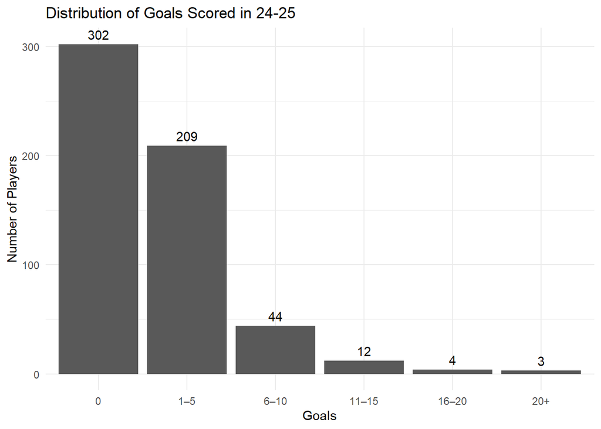

```r
df %>%
  mutate(
    Goals_Bin = cut(
      Gls,
      breaks = c(-1, 0, 5, 10, 15, 20, Inf),
      labels = c("0", "1–5", "6–10", "11–15", "16–20", "20+")
    )
  ) %>%
  ggplot(aes(x = Goals_Bin)) +
  geom_bar() +
  geom_text(
    stat = "count",
    aes(label = after_stat(count)),
    vjust = -0.5
  ) +
  geom_bar() +
  labs(
    title = "Distribution of Goals Scored in 24-25",
    x = "Goals",
    y = "Number of Players"
  ) +
  theme_minimal()
```

This shows how it is relatively rare to find a player who scores more than 15 goals a season.

The apparent rareness of goals motivates a quick look to at the mean goals per game.

```r
mean_goals_per_game = sum(df$Gls)/(38*10)
print(mean_goals_per_game)
```

```
## [1] 2.847368
```

Awesome, so we can expect around three goals in the average game in the 2025-25 season. It is an indication that game scores tend to be quite low. This can be shown to be the case when we consider historic game data. This is a problem which has been alluded in literature where poisson models for goals per game have to be adjusted to make 0-0, and 1-0 outcomes more likely.

Lets further explore some boxplots for this data, lets look at how different positions are performing in front of goal:

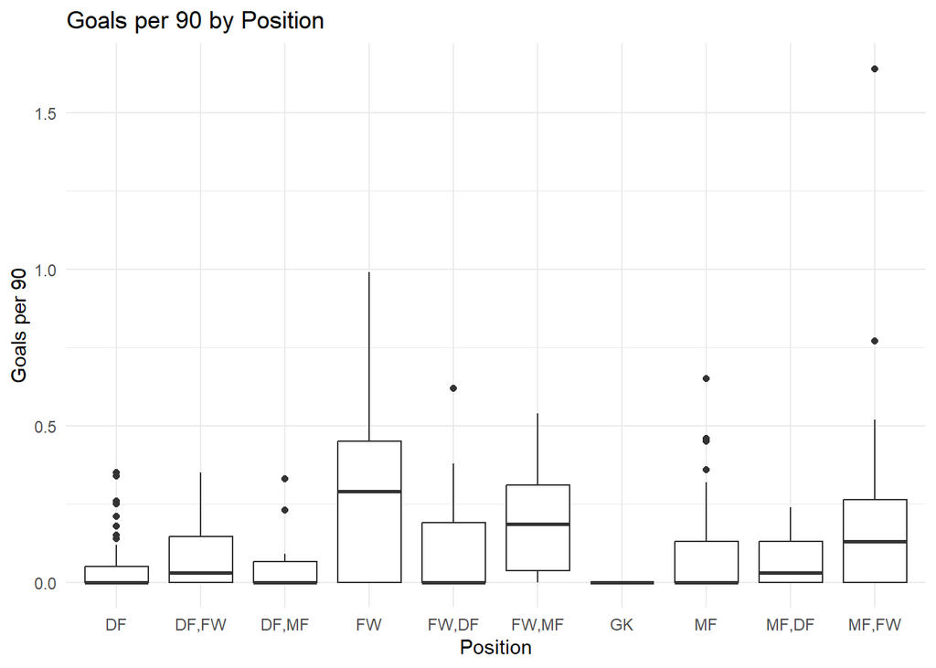

```r
ggplot(df, aes(x = Pos, y = Gls_Per)) +
  geom_boxplot() +
  labs(
    title = "Goals per 90 by Position",
    x = "Position",
    y = "Goals per 90"
  ) +
  theme_minimal()
```

We have that: (Gk, Df, MF, FW) denotes the positions of goalkeeper, defender, midfielder, and forwards. Since some players play a combination of these positions. Note that although seemingly unlikely for a defender / forward, players who fall into this role in the data tend to be wing backs who play further forward / backward depending on the system employed in any match.

As to be expected, the forwards have the greatest mean goals per 90. Quite a few outliers in the MF category, this could be down to exceptional attacking returns for a few very good players.

```r
df %>%
  filter(Pos == "MF") %>%
  arrange(desc(Gls_Per)) %>%
  select(Player, Squad, Gls_Per, Gls, Min_Playing) %>%
  slice_head(n = 10)
```

```
## # A tibble: 10 × 5
##    Player           Squad          Gls_Per   Gls Min_Playing
##    <chr>            <chr>            <dbl> <dbl>       <dbl>
##  1 Romain Esse      Crystal Palace    0.65     1         138
##  2 Ross Barkley     Aston Villa       0.46     3         581
##  3 Justin Kluivert  Bournemouth       0.46    12        2340
##  4 James Maddison   Tottenham         0.45     9        1809
##  5 Marco Asensio    Aston Villa       0.36     3         743
##  6 Tomáš Souček     West Ham          0.32     9        2567
##  7 Tom Cairney      Fulham            0.29     2         628
##  8 Lewis Miley      Newcastle Utd     0.29     1         313
##  9 Ismaila Sarr     Crystal Palace    0.27     8        2711
## 10 Emile Smith Rowe Fulham            0.26     6        2043
```

Yeah okay so kind of as expected, we have players like Soucek who score very often for a genuine MF, but we also have objectively worse players such as Esse having inflated Goals per 90, since they have played such few minutes.

Now we’re just going to check what was going on with the ages that returned as NAs:

```r
df %>%
  filter(is.na(Age)) %>%
  select(Player, Squad, Season_End_Year, Born, Age)
```

```
## # A tibble: 4 × 5
##   Player        Squad          Season_End_Year  Born   Age
##   <chr>         <chr>                    <dbl> <dbl> <dbl>
## 1 Olabade Aluko Leicester City            2025    NA    NA
## 2 Jake Evans    Leicester City            2025    NA    NA
## 3 Jeremy Monga  Leicester City            2025    NA    NA
## 4 Mateus Mane   Wolves                    2025    NA    NA
```

Ahh, okay so the players with no age also have no year born. We could remove these but equally as easy we can just fill in the data:

```r
df <- df %>%
  mutate(
    Age = case_when(
      Player == "Olabade Aluko" ~ 18,
      Player == "Jake Evans" ~ 16,
      Player == "Jeremy Monga" ~ 15,
      Player == "Mateus Mane" ~ 17,
      TRUE ~ Age
    )
  )
```

Now let us check the update worked:

```r
df %>%
  filter(is.na(Age)) %>%
  select(Player, Squad, Season_End_Year, Born, Age)
```

```
## # A tibble: 0 × 5
## # ℹ 5 variables: Player <chr>, Squad <chr>, Season_End_Year <dbl>, Born <dbl>,
## #   Age <dbl>
```

Note that all the players where young, and so it is plausible that their ages where not publicly disclosed, or just found when fbref collected their data.

Overall, the data here seems pretty plausible and should be ready for us to use.